# EP09 - equipo 10

A continuación se detallan los procedimientos para el estudio:

#### *1. Definir la semilla a utilizar, que corresponde a los últimos cuatro dígitos del RUN (sin considerar el dígito verificador) del integrante de menor edad del equipo*

```r
set.seed(7416)
```

#### *2. Seleccionar una muestra aleatoria de 100 mujeres (si la semilla es un número par) o 100 hombres (si la semilla es impar), y separar 70 casos para trabajar en la construcción de modelos y 30 para su evaluación en datos no vistos*

Al tener una semilla par, se eligen 100 mujeres:

```r
datos <- read.csv2("EP09 Datos.csv")

datos <- datos[datos$Gender == "0",]

muestra <- sample_n(datos, 100)
muestraModelo <- head(muestra,70)
print(muestraModelo)
```

```
##    Biacromial.diameter Biiliac.diameter Bitrochanteric.diameter Chest.depth
## 1                 38.5             25.6                    31.7        17.0
## 2                 36.7             28.2                    33.0        17.5
## 3                 33.9             24.3                    29.5        15.8
## 4                 36.2             31.1                    34.7        21.1
## 5                 36.5             27.0                    31.6        16.6
## 6                 38.9             28.5                    34.0        19.2
## 7                 38.7             29.7                    32.0        15.8
## 8                 40.7             29.0                    35.3        17.7
## 9                 38.7             23.5                    33.0        16.4
## 10                34.8             25.9                    30.2        16.4
## 11                35.1             23.7                    31.1        18.5
## 12                35.0             27.0                    33.0        19.3
## 13                34.0             27.3                    29.9        17.0
## 14                36.9             29.0                    33.7        15.6
```

[output cut: 340 more lines]

#### *4. Seleccionar, de las otras variables, una que el equipo considere que podría ser útil para predecir la variable Peso (sin considerar la estatura), justificando bien esta selección*

De las variables no seleccionadas aleatoriamente, se optó por *Navel.Girth* (grosor a la altura del ombligo) para predecir el peso. De esta forma, la elección se baso en el artículo de Cedeño et. al, donde también se utiliza esta medida como predictor para el sobrepeso. Además, se indica que esta variable *“se ha establecido como estándar antropométrico de la obesidad abdominal … debido a su simplicidad de medida y a su correlación con la grasa abdominal”*, por lo que, coincide perfectamente con lo buscado.

#### *5. Usando el entorno R y paquetes estándares1, construir un modelo de regresión lineal simple con el predictor seleccionado en el paso anterior*

```r
#testeo modelo 1
modelo <- lm( Weight ~ Navel.Girth, data = muestraModelo)
print(summary(modelo))
```

```
##
## Call:
## lm(formula = Weight ~ Navel.Girth, data = muestraModelo)
##
## Residuals:
##      Min       1Q   Median       3Q      Max
## -13.2428  -3.1362  -0.1112   3.7926  15.6114
##
## Coefficients:
##             Estimate Std. Error t value Pr(>|t|)
## (Intercept)  1.31961    5.27311    0.25    0.803
## Navel.Girth  0.70387    0.06362   11.06   <2e-16 ***
## ---
## Signif. codes:  0 '***' 0.001 '**' 0.01 '*' 0.05 '.' 0.1 ' ' 1
##
## Residual standard error: 5.202 on 68 degrees of freedom
## Multiple R-squared:  0.6429, Adjusted R-squared:  0.6376
## F-statistic: 122.4 on 1 and 68 DF,  p-value: < 2.2e-16
```

```r
print(AIC(modelo))
```

```
## [1] 433.4934
```

#### *6. Usando herramientas estándares1 para la exploración de modelos del entorno R, buscar entre dos y cinco predictores de entre las variables seleccionadas al azar en el punto 3, para agregar al modelo de regresión lineal simple obtenido en el paso 5*

```r
#testeo modelo 2
modelo1 <- lm(Weight ~ Navel.Girth  + Thigh.Girth, data = muestraModelo)
print(summary(modelo1))
```

```
##
## Call:
## lm(formula = Weight ~ Navel.Girth + Thigh.Girth, data = muestraModelo)
##
## Residuals:
##     Min      1Q  Median      3Q     Max
## -8.9088 -2.6942 -0.1841  2.5145 11.9808
##
## Coefficients:
##              Estimate Std. Error t value Pr(>|t|)
## (Intercept) -30.04270    5.94115  -5.057 3.53e-06 ***
## Navel.Girth   0.37084    0.06712   5.525 5.82e-07 ***
## Thigh.Girth   1.03339    0.14467   7.143 8.39e-10 ***
## ---
## Signif. codes:  0 '***' 0.001 '**' 0.01 '*' 0.05 '.' 0.1 ' ' 1
##
## Residual standard error: 3.949 on 67 degrees of freedom
## Multiple R-squared:  0.7973, Adjusted R-squared:  0.7912
## F-statistic: 131.7 on 2 and 67 DF,  p-value: < 2.2e-16
```

```r
print(AIC(modelo1))
```

```
## [1] 395.8594
```

```r
anova1 <- anova(modelo,modelo1)
print(anova1)
```

```
## Analysis of Variance Table
##
## Model 1: Weight ~ Navel.Girth
## Model 2: Weight ~ Navel.Girth + Thigh.Girth
##   Res.Df    RSS Df Sum of Sq      F    Pr(>F)
## 1     68 1840.3
## 2     67 1044.7  1    795.59 51.024 8.393e-10 ***
## ---
## Signif. codes:  0 '***' 0.001 '**' 0.01 '*' 0.05 '.' 0.1 ' ' 1
```

```r
#testeo modelo 3
modelo2 <- lm(Weight ~ Navel.Girth  + Thigh.Girth + Waist.Girth, data = muestraModelo)
print(summary(modelo2))
```

```
##
## Call:
## lm(formula = Weight ~ Navel.Girth + Thigh.Girth + Waist.Girth,
##     data = muestraModelo)
##
## Residuals:
##     Min      1Q  Median      3Q     Max
## -9.0731 -1.8751 -0.0349  2.1696  7.3949
##
## Coefficients:
##              Estimate Std. Error t value Pr(>|t|)
## (Intercept) -33.58477    5.38268  -6.239 3.55e-08 ***
## Navel.Girth   0.14525    0.08054   1.803   0.0759 .
## Thigh.Girth   0.87232    0.13501   6.461 1.45e-08 ***
## Waist.Girth   0.45503    0.10824   4.204 8.06e-05 ***
## ---
## Signif. codes:  0 '***' 0.001 '**' 0.01 '*' 0.05 '.' 0.1 ' ' 1
##
## Residual standard error: 3.533 on 66 degrees of freedom
## Multiple R-squared:  0.8401, Adjusted R-squared:  0.8328
## F-statistic: 115.6 on 3 and 66 DF,  p-value: < 2.2e-16
```

```r
print(AIC(modelo2))
```

```
## [1] 381.2502
```

```r
comparacion <- anova(modelo1,modelo2)
print(comparacion)
```

```
## Analysis of Variance Table
##
## Model 1: Weight ~ Navel.Girth + Thigh.Girth
## Model 2: Weight ~ Navel.Girth + Thigh.Girth + Waist.Girth
##   Res.Df     RSS Df Sum of Sq      F   Pr(>F)
## 1     67 1044.68
## 2     66  824.02  1    220.66 17.674 8.06e-05 ***
## ---
## Signif. codes:  0 '***' 0.001 '**' 0.01 '*' 0.05 '.' 0.1 ' ' 1
```

```r
#testeo modelo 4
modelo3 <- lm(Weight ~ Navel.Girth  + Thigh.Girth + Waist.Girth +Shoulder.Girth,data=muestraModelo)
print(AIC(modelo3))
```

```
## [1] 369.0005
```

```r
print(anova(modelo2,modelo3))
```

```
## Analysis of Variance Table
##
## Model 1: Weight ~ Navel.Girth + Thigh.Girth + Waist.Girth
## Model 2: Weight ~ Navel.Girth + Thigh.Girth + Waist.Girth + Shoulder.Girth
##   Res.Df    RSS Df Sum of Sq      F    Pr(>F)
## 1     66 824.02
## 2     65 672.25  1    151.77 14.675 0.0002903 ***
## ---
## Signif. codes:  0 '***' 0.001 '**' 0.01 '*' 0.05 '.' 0.1 ' ' 1
```

```r
#testeo modelo 5
modelo4 <- lm(Weight ~ Navel.Girth  + Thigh.Girth + Waist.Girth +Shoulder.Girth + Calf.Maximum.Girth ,data=muestraModelo)
print(AIC(modelo4))
```

```
## [1] 349.2275
```

```r
print(anova(modelo3,modelo4))
```

```
## Analysis of Variance Table
##
## Model 1: Weight ~ Navel.Girth + Thigh.Girth + Waist.Girth + Shoulder.Girth
## Model 2: Weight ~ Navel.Girth + Thigh.Girth + Waist.Girth + Shoulder.Girth +
##     Calf.Maximum.Girth
##   Res.Df    RSS Df Sum of Sq     F    Pr(>F)
## 1     65 672.25
## 2     64 492.54  1     179.7 23.35 8.799e-06 ***
## ---
## Signif. codes:  0 '***' 0.001 '**' 0.01 '*' 0.05 '.' 0.1 ' ' 1
```

#### *7. Evaluar la bondad de ajuste (incluyendo el análisis de casos atípicos y casos influyentes) y la generalidad (condiciones para RLM) de los modelos y “arreglarlos” en caso de que presenten algún problema.*

Para este apartado, es necesario comprobar que se cumplan las siguientes condiciones:

1. La variable de respuesta debe ser cuantitativa y continua, sin restricciones para su variabilidad.
2. Los predictores deben ser cuantitativos o dicotómicos.
3. Los predictores deben tener algún grado de variabilidad.
4. Cada predictor debe estar relacionado linealmente con la respuesta.
5. La distribución de residuos debe ser cercana a la normal centrada en cero.
6. La variabilidad de los residuos debe ser aproximadamente constante.
7. Los residuos deben ser independientes entre sí.
8. No debe existir multicolinealidad.
9. Las estimaciones de los coeficientes del modelo no deben estar alterados por unas pocas observaciones influyentes.

Las primeras 3 condiciones (1, 2 y 3) se cumplen, pues el peso es una variable cuantitativa y continua, además todos los predictores son cuantitativos y presentan variabilidad.

Para verificar el cumplimiento de las siguientes 3 condiciones (4, 5 y 6), se realizan gráficos residuales y marginales para cada variable:

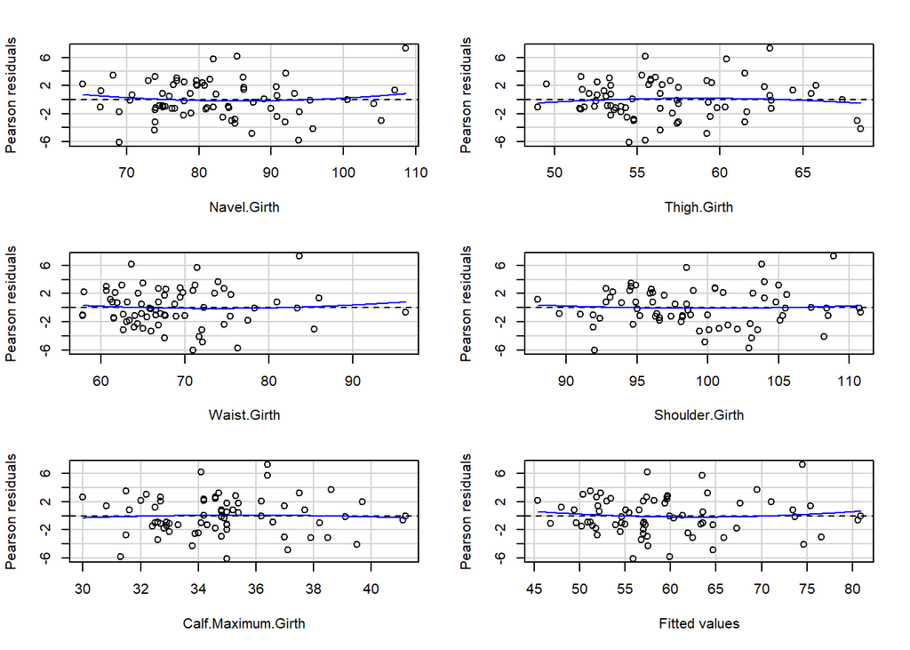

```
##                    Test stat Pr(>|Test stat|)
## Navel.Girth           0.8222           0.4141
## Thigh.Girth          -0.5107           0.6114
## Waist.Girth           0.5004           0.6186
## Shoulder.Girth        0.3220           0.7485
## Calf.Maximum.Girth   -0.2849           0.7767
## Tukey test            0.6484           0.5167
```

```r
graficoResidual <- residualPlots(modelo4)
```

```r
print(graficoResidual)
```

```
##                     Test stat Pr(>|Test stat|)
## Navel.Girth         0.8221961        0.4140663
## Thigh.Girth        -0.5106745        0.6113639
## Waist.Girth         0.5003581        0.6185664
## Shoulder.Girth      0.3219878        0.7485280
## Calf.Maximum.Girth -0.2848987        0.7766562
## Tukey test          0.6483862        0.5167352
```

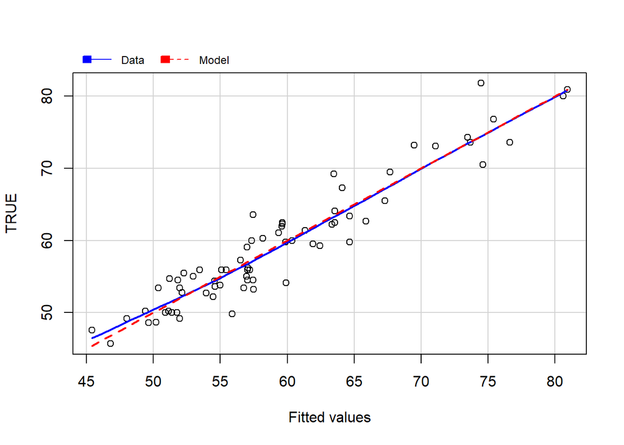

```r
graficoMarginal <- marginalModelPlot(modelo4)
```

De los cuales se cumplen las condiciones.

Luego, para la condición 7, se realiza un test Durbin Watson, para verificar que los residuos sean independientes entre sí:

```r
durbinWatsonTest(modelo4)
```

```
##  lag Autocorrelation D-W Statistic p-value
##    1     -0.01863419      2.013754   0.998
##  Alternative hypothesis: rho != 0
```

Para la condición 8, se utiliza VIF para verificar que no exista colinealidad:

```r
vif(modelo4)
```

```
##        Navel.Girth        Thigh.Girth        Waist.Girth     Shoulder.Girth
##           3.774895           2.701706           3.550045           2.260299
## Calf.Maximum.Girth
##           2.175987
```

En el que se concluye que no hay colinealidad, pues para que una VIF sea confiable o preocupante (respecto a la existencia de colinealidad), es necesario que los valores estén entre 1 y 5, de esta forma, en base a los valores obtenidos podemos confiar en los datos, y que en el caso de existir colinealidad no afectará la confiabilidad del modelo

Finalmente, para la condición 9 se realiza un gráfico de influencia para verificar si hay observaciones atípicas influyentes, en el caso de existir, ésta debe ser eliminada:

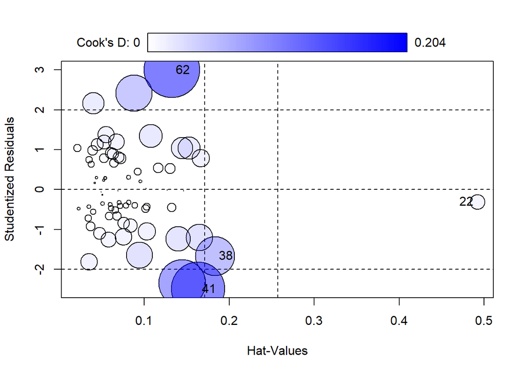

|  | StudRes | Hat | CookD |
| --- | --- | --- | --- |
| 22 | -0.3030432 | 0.4919170 | 0.01503218 |
| 38 | -1.6650038 | 0.1833073 | 0.10091077 |
| 41 | -2.4886200 | 0.1633870 | 0.18645548 |
| 62 | 3.0003485 | 0.1327542 | 0.20414238 |

```r
influencePlot(modelo4)
```

```r
print(influencePlot(modelo4))
```

```
##       StudRes       Hat      CookD
## 22 -0.3030432 0.4919170 0.01503218
## 38 -1.6650038 0.1833073 0.10091077
## 41 -2.4886200 0.1633870 0.18645548
## 62  3.0003485 0.1327542 0.20414238
```

Como se puede apreciar, el modelo presenta una dato atípico por lo que se procede a quitar el dato e intentar el mismo procedimiento:

```r
modeloNuevo <- muestraModelo[-c(22),] #formula para quitar el dato atípico

#se recrea el modelo con la nueva data.
modeloAjustado <- lm( Weight ~ Navel.Girth, data = modeloNuevo)
print(AIC(modeloAjustado))
```

```
## [1] 427.2008
```

```r
print(summary(modeloAjustado))
```

```
##
## Call:
## lm(formula = Weight ~ Navel.Girth, data = modeloNuevo)
##
## Residuals:
##      Min       1Q   Median       3Q      Max
## -12.9397  -3.0387  -0.2577   3.7882  15.6469
##
## Coefficients:
##             Estimate Std. Error t value Pr(>|t|)
## (Intercept)  2.80959    5.44670   0.516    0.608
## Navel.Girth  0.68476    0.06599  10.377  1.4e-15 ***
## ---
## Signif. codes:  0 '***' 0.001 '**' 0.01 '*' 0.05 '.' 0.1 ' ' 1
##
## Residual standard error: 5.196 on 67 degrees of freedom
## Multiple R-squared:  0.6164, Adjusted R-squared:  0.6107
## F-statistic: 107.7 on 1 and 67 DF,  p-value: 1.404e-15
```

```r
modeloAjustado2 <- lm(Weight ~ Navel.Girth + Thigh.Girth, data=modeloNuevo)
print(AIC(modeloAjustado2))
```

```
## [1] 379.278
```

```r
print(summary(modeloAjustado2))
```

```
##
## Call:
## lm(formula = Weight ~ Navel.Girth + Thigh.Girth, data = modeloNuevo)
##
## Residuals:
##     Min      1Q  Median      3Q     Max
## -8.2323 -2.7046  0.0868  2.2963  8.1486
##
## Coefficients:
##             Estimate Std. Error t value Pr(>|t|)
## (Intercept) -30.1365     5.4862  -5.493 6.81e-07 ***
## Navel.Girth   0.2863     0.0664   4.312 5.52e-05 ***
## Thigh.Girth   1.1538     0.1378   8.371 5.75e-12 ***
## ---
## Signif. codes:  0 '***' 0.001 '**' 0.01 '*' 0.05 '.' 0.1 ' ' 1
##
## Residual standard error: 3.646 on 66 degrees of freedom
## Multiple R-squared:  0.814,  Adjusted R-squared:  0.8083
## F-statistic: 144.4 on 2 and 66 DF,  p-value: < 2.2e-16
```

```r
anovaAjustado <- anova(modeloAjustado,modeloAjustado2)
print(anovaAjustado)
```

```
## Analysis of Variance Table
##
## Model 1: Weight ~ Navel.Girth
## Model 2: Weight ~ Navel.Girth + Thigh.Girth
##   Res.Df     RSS Df Sum of Sq     F    Pr(>F)
## 1     67 1809.11
## 2     66  877.49  1    931.61 70.07 5.749e-12 ***
## ---
## Signif. codes:  0 '***' 0.001 '**' 0.01 '*' 0.05 '.' 0.1 ' ' 1
```

```r
modeloAjustado3 <- lm(Weight ~ Navel.Girth  + Thigh.Girth + Waist.Girth, data = modeloNuevo)
print(AIC(modeloAjustado3))
```

```
## [1] 374.1062
```

```r
print(summary(modeloAjustado3))
```

```
##
## Call:
## lm(formula = Weight ~ Navel.Girth + Thigh.Girth + Waist.Girth,
##     data = modeloNuevo)
##
## Residuals:
##     Min      1Q  Median      3Q     Max
## -8.0914 -1.8213 -0.0673  2.1512  7.4701
##
## Coefficients:
##              Estimate Std. Error t value Pr(>|t|)
## (Intercept) -32.74076    5.33825  -6.133 5.71e-08 ***
## Navel.Girth   0.15728    0.07984   1.970  0.05311 .
## Thigh.Girth   0.97696    0.14758   6.620 8.10e-09 ***
## Waist.Girth   0.34021    0.12750   2.668  0.00962 **
## ---
## Signif. codes:  0 '***' 0.001 '**' 0.01 '*' 0.05 '.' 0.1 ' ' 1
##
## Residual standard error: 3.488 on 65 degrees of freedom
## Multiple R-squared:  0.8323, Adjusted R-squared:  0.8246
## F-statistic: 107.5 on 3 and 65 DF,  p-value: < 2.2e-16
```

```r
anovaAjustado2 <- anova(modeloAjustado2,modeloAjustado3)
print(anovaAjustado2)
```

```
## Analysis of Variance Table
##
## Model 1: Weight ~ Navel.Girth + Thigh.Girth
## Model 2: Weight ~ Navel.Girth + Thigh.Girth + Waist.Girth
##   Res.Df    RSS Df Sum of Sq      F   Pr(>F)
## 1     66 877.49
## 2     65 790.87  1    86.626 7.1197 0.009616 **
## ---
## Signif. codes:  0 '***' 0.001 '**' 0.01 '*' 0.05 '.' 0.1 ' ' 1
```

```r
#Modelo 4 que contiene navel, thigh, waist y shoulder
modeloAjustado4 <- lm(Weight ~ Navel.Girth  + Thigh.Girth + Waist.Girth + Shoulder.Girth, data = modeloNuevo)
print(AIC(modeloAjustado4))
```

```
## [1] 362.9432
```

```r
print(summary(modeloAjustado4))
```

```
##
## Call:
## lm(formula = Weight ~ Navel.Girth + Thigh.Girth + Waist.Girth +
##     Shoulder.Girth, data = modeloNuevo)
##
## Residuals:
##     Min      1Q  Median      3Q     Max
## -8.5950 -2.2547 -0.1667  1.8792  6.8856
##
## Coefficients:
##                 Estimate Std. Error t value Pr(>|t|)
## (Intercept)    -54.90770    7.77463  -7.062 1.45e-09 ***
## Navel.Girth      0.08524    0.07574   1.126   0.2646
## Thigh.Girth      0.86552    0.13857   6.246 3.83e-08 ***
## Waist.Girth      0.30738    0.11715   2.624   0.0109 *
## Shoulder.Girth   0.37044    0.10100   3.668   0.0005 ***
## ---
## Signif. codes:  0 '***' 0.001 '**' 0.01 '*' 0.05 '.' 0.1 ' ' 1
##
## Residual standard error: 3.195 on 64 degrees of freedom
## Multiple R-squared:  0.8614, Adjusted R-squared:  0.8528
## F-statistic: 99.47 on 4 and 64 DF,  p-value: < 2.2e-16
```

```r
anovaAjustado3 <- anova(modeloAjustado3,modeloAjustado4)
print(anovaAjustado3)
```

```
## Analysis of Variance Table
##
## Model 1: Weight ~ Navel.Girth + Thigh.Girth + Waist.Girth
## Model 2: Weight ~ Navel.Girth + Thigh.Girth + Waist.Girth + Shoulder.Girth
##   Res.Df    RSS Df Sum of Sq      F Pr(>F)
## 1     65 790.87
## 2     64 653.51  1    137.35 13.451  5e-04 ***
## ---
## Signif. codes:  0 '***' 0.001 '**' 0.01 '*' 0.05 '.' 0.1 ' ' 1
```

```r
modeloAjustado5 <- lm(Weight ~ Navel.Girth  + Thigh.Girth + Waist.Girth +Shoulder.Girth+ Calf.Maximum.Girth,data=modeloNuevo)
#Se llega a un modelo que retorna un AIC de 345, mas pequeño que todo lo obtenido hasta ahora
print(anova(modeloAjustado4,modeloAjustado5))
```

```
## Analysis of Variance Table
##
## Model 1: Weight ~ Navel.Girth + Thigh.Girth + Waist.Girth + Shoulder.Girth
## Model 2: Weight ~ Navel.Girth + Thigh.Girth + Waist.Girth + Shoulder.Girth +
##     Calf.Maximum.Girth
##   Res.Df    RSS Df Sum of Sq      F    Pr(>F)
## 1     64 653.51
## 2     63 491.83  1    161.69 20.711 2.495e-05 ***
## ---
## Signif. codes:  0 '***' 0.001 '**' 0.01 '*' 0.05 '.' 0.1 ' ' 1
```

Se vuelven a verificar las condiciones:

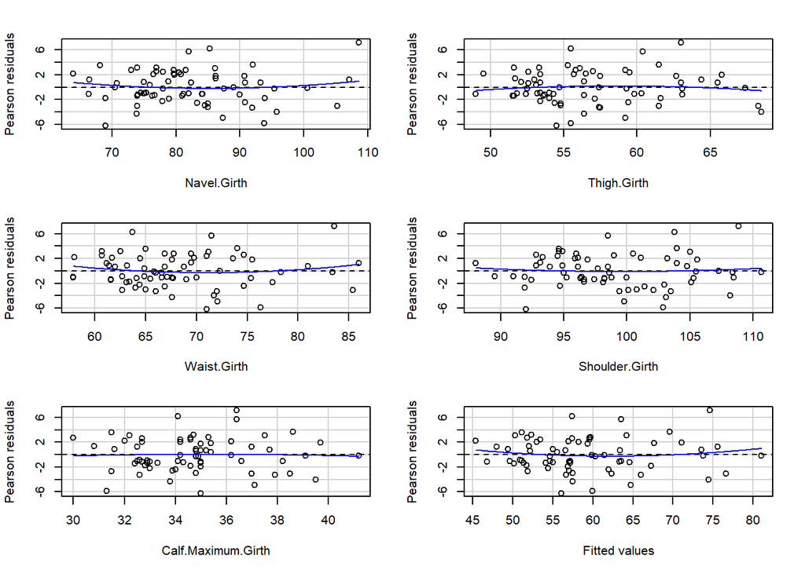

```
##                    Test stat Pr(>|Test stat|)
## Navel.Girth           0.8334           0.4078
## Thigh.Girth          -0.5605           0.5772
## Waist.Girth           0.9934           0.3244
## Shoulder.Girth        0.3937           0.6952
## Calf.Maximum.Girth   -0.1864           0.8527
## Tukey test            0.7846           0.4327
```

```r
graficoResidual <- residualPlots(modeloAjustado5)
```

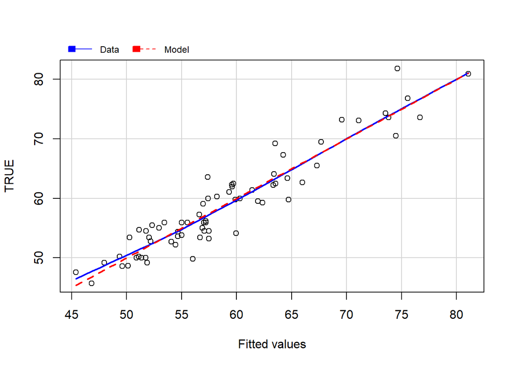

```r
graficoMarginal <- marginalModelPlot(modeloAjustado5)
```

Verificar que los residuos sean independientes entre sí:

```r
durbinWatsonTest(modeloAjustado5) #p-value = 0.77, No existe alguna depedencia
```

```
##  lag Autocorrelation D-W Statistic p-value
##    1      -0.0411304      2.059067    0.77
##  Alternative hypothesis: rho != 0
```

Se obtiene un p-value = 0.77, por lo que nuevamente no es posible rechazar que los residuos sean independientes entre sí.

Verificar que no haya colinealidad.

```r
vif(modeloAjustado5)
```

```
##        Navel.Girth        Thigh.Girth        Waist.Girth     Shoulder.Girth
##           3.518040           3.878537           3.928959           2.104490
## Calf.Maximum.Girth
##           2.291648
```

Como se mencionó anteriormente, cumple nuevamente con los rangos por lo que se puede concluir que no hay colinealidad, y en el caso de existir no afectará la confiabilidad del modelo.

Verificar si aún hay observaciones atípicas influyentes.

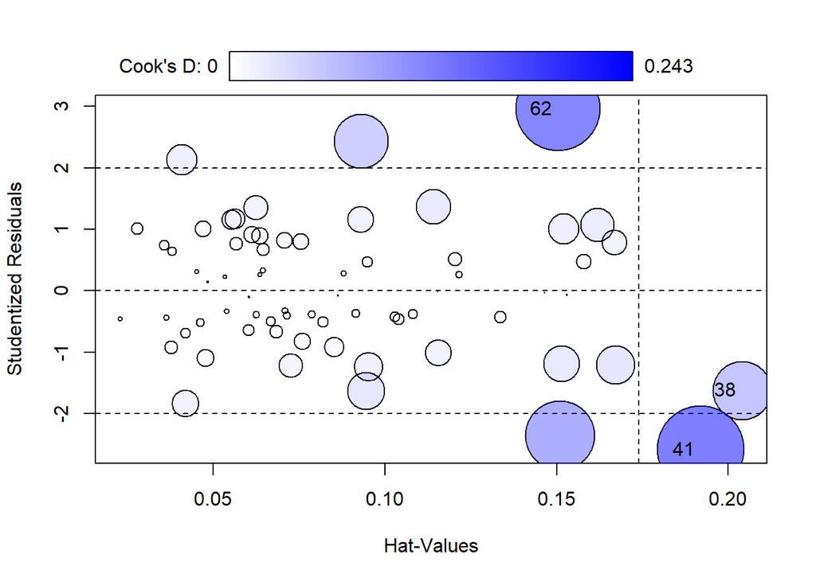

|  | StudRes | Hat | CookD |
| --- | --- | --- | --- |
| 38 | -1.623599 | 0.2040263 | 0.1097639 |
| 41 | -2.584157 | 0.1919716 | 0.2425608 |
| 62 | 2.961167 | 0.1503975 | 0.2303033 |

```r
influencePlot(modeloAjustado5)
```

```r
print(influencePlot(modeloAjustado5))
```

```
##      StudRes       Hat     CookD
## 38 -1.623599 0.2040263 0.1097639
## 41 -2.584157 0.1919716 0.2425608
## 62  2.961167 0.1503975 0.2303033
```

#### *8. Evaluar el poder predictivo del modelo con los datos no utilizados para construirlo.*

```r
#Testeo poder predictivo
muestranueva <- tail(muestra,30)
form <- formula("Weight ~ Navel.Girth  + Thigh.Girth + Waist.Girth +Shoulder.Girth+ Calf.Maximum.Girth")
entrenamiento <- train(form, data = muestranueva, method = "lm", tr = trainControl(method="LOOCV"))
print(entrenamiento)
```

```
## Linear Regression
##
## 30 samples
##  5 predictor
##
## No pre-processing
## Resampling: Bootstrapped (25 reps)
## Summary of sample sizes: 30, 30, 30, 30, 30, 30, ...
## Resampling results:
##
##   RMSE      Rsquared   MAE
##   2.652006  0.8859625  2.16266
##
## Tuning parameter 'intercept' was held constant at a value of TRUE
```

```r
mean_weight <- mean(muestranueva$Weight)
sd_weight_test <- sd(muestranueva$Weight)
rmse_relative <- 2.652006 / mean_weight * 100
print(rmse_relative)
```

```
## [1] 4.394133
```

```r
print(sd_weight_test)
```

```
## [1] 8.092897
```

```r
print(mean_weight)
```

```
## [1] 60.35333
```

```r
#Uso del predict
predicciones <- predict(modeloAjustado5, newdata = muestranueva)

# dataframe de comparación
resultados <- data.frame(
  Real = muestranueva$Weight,
  Predicho = predicciones,
  Residuo = muestranueva$Weight - predicciones
)
print(resultados)
```

```
##     Real Predicho    Residuo
## 71  54.5 52.24606  2.2539385
## 72  60.3 60.88917 -0.5891696
## 73  62.3 57.42917  4.8708264
## 74  53.2 52.78131  0.4186868
## 75  82.5 78.21594  4.2840550
## 76  55.5 54.65119  0.8488060
## 77  54.4 58.56240 -4.1624008
## 78  55.4 56.47697 -1.0769724
## 79  59.8 60.92487 -1.1248724
## 80  45.9 46.14157 -0.2415743
## 81  70.6 66.72331  3.8766882
## 82  56.0 57.50239 -1.5023938
## 83  56.8 57.90192 -1.1019162
## 84  72.9 70.72039  2.1796107
```

[output cut: 16 more lines]

De lo anterior, se obtuvo un valor de RMSE = 2.652006, es decir, un peso de 2.65kg con un error de 4.394133 o 4.39% respecto al peso promedio (60.35kg aproximadamente). Además, los resultados obtenidos son bastante similares en la mayoría de los casos, por lo que es posible decir que el modelo predice correctamente o apunta a predecir correctamente el peso corporal, pero de todas formas podrían realizarse más observaciones con mayor profundidad para reducir los errores existentes.

#### *Bibliografía*

Cedeño Morales, Raúl, Castellanos González, Maricel, Benet Rodríguez, Mikhail, Mass Sosa, Luis, Mora Hernández, Carlos, & Parada Arias, Jorge. (2015). Indicadores antropométricos para determinar la obesidad, y sus relaciones con el riesgo cardiometabólico: cifras alarmantes. Revista Finlay, 5(1), 12-23. Recuperado en 06 de junio de 2025, de http://scielo.sld.cu/scielo.php?script=sci_arttext&pid=S2221-24342015000100003&lng=es&tlng=es.